# Building Models for Stratigraphic Paleobiology in R: Workshop Materials and Cheat Sheets

Author

Niklas Hohmann

This document contains the *tasks* and the *coding cheat sheets* for the workshop *Building Models for Stratigraphic Paleobiology in R*.

## Getting help

To find the documentation of a function, prepend its name with a question mark and execute it in the console (e.g., `?random_walk`). The help pages are also available on the package webpage (mindthegap-erc.github.io/StratPal/) under “Reference”.  
Long form documentation (vignettes) can be found on the webpage under “Articles” or via `browseVignettes("StratPal")`.

## Practical 1: Age-depth models and incompleteness (45 min)

This practical is an introduction to age-depth models and stratigraphic (in)completeness.

### Tasks

1. Define age-depth models for different locations along the onshore-offshore gradient, and plot them.
   - How do they connect to the chronostratigraphic diagram and the sea level curve shows below?
2. Examine how stratigraphic incompleteness and the number of hiatuses changes along the onshore-offshore gradient.
3. Generate histograms of hiatus durations at the different distances from shore.
   - Do you see any systematic changes?

### Basin transect and chronostratigraphic diagram

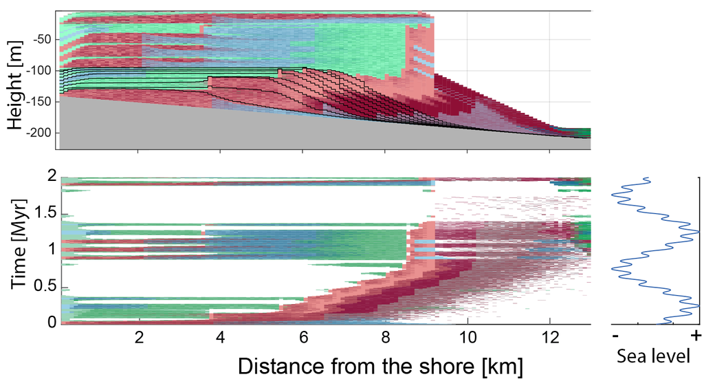

### Coding cheat sheet

#### Loading the package and data

Load the `StratPal` and `admtools` packages via

```r
library("StratPal")
library("admtools")
```

to have all required functionality and example data available. We use the example data stored in the `scenarioA` variable that comes with the `StratPal` package. You can find more details on the data using `?scenarioA`.

#### Creating age-depth models

Age-depth models are constructed using `tp_to_adm` (tie point to age-depth model) from the `admtools` package. Here we construct the age-depth model 2 km from shore by passing the function the vectors of times and heights at that stratigraphic position:

```r
pos = "2km"                                 # distance from shore
adm = tp_to_adm(t = scenarioA$t_myr,        # construct age-depth model
                h = scenarioA$h_m[,pos],
                T_unit = "Myr",
                L_unit = "m")
```

Note that we immediately add time and length units to avoid downstream confusion. The example data contains model outputs at 2, 4, 6, 8, 10, and 12 km from shore.

#### Plotting Age-depth models

Age-depth models can be plotted using the standard `plot` command:

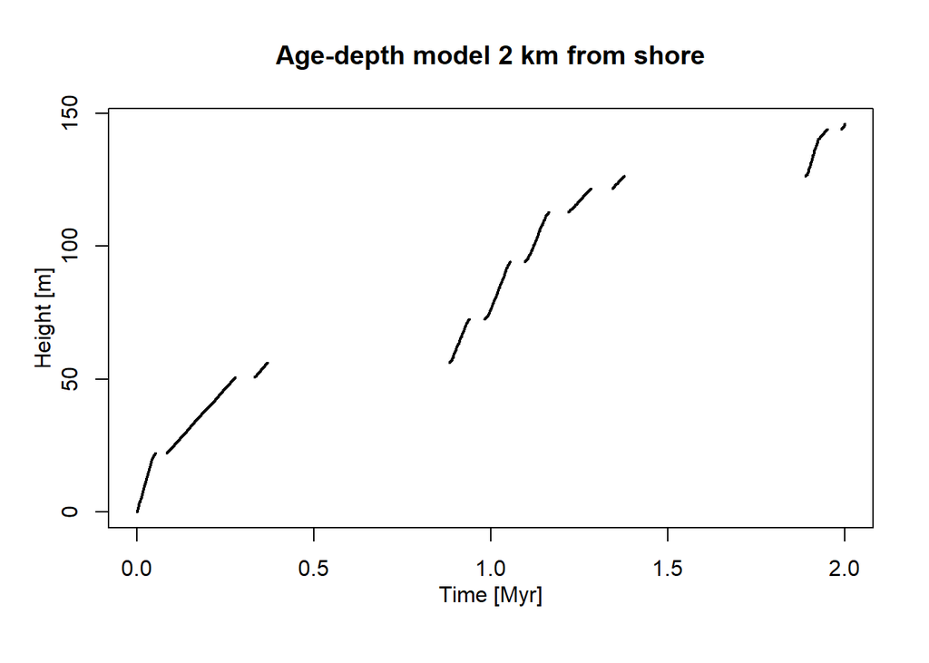

```r
plot(adm,           # Plot age-depth model
     lwd_acc = 2,   # plot thicker lines for intervals with sediment accumulation (lwd = line width)
     lty_destr = 0) # don't plot destructive intervals/gaps (lty = line type)
T_axis_lab()        # add time axis label
L_axis_lab()        # add length axis label
title("Age-depth model 2 km from shore")
```

See `?plot.adm` for more plotting options.

#### Extracting information from age-depth models

Age-depth models contain a lot of stratigraphic information, e.g. on stratigraphic completeness, hiatuses, or sedimentation rates. Some basic functionality to extract this information is:

```r
get_total_duration(adm)  # time interval covered by age-depth model
```

```
[1] 1.999
```

```r
get_total_thickness(adm) # sediment accumulated
```

```
[1] 145.9416
```

```r
get_completeness(adm)    # stratigraphic completeness
```

```
[1] 0.3261631
```

```r
get_hiat_duration(adm)   # extract hiatus durations
```

```
 [1] 0.001 0.031 0.054 0.513 0.042 0.041 0.055 0.061 0.511 0.038
```

```r
summary(adm)             # some summary statistics
```

```
age-depth model
Total duration: 1.999 Myr
Total thickness: 145.9416 m
Stratigraphic completeness: 32.61631 %
10 hiatus(es)
```

You can find a comprehensive list of functions that extract information from age-depth models [here](https://mindthegap-erc.github.io/admtools/articles/admtools_doc.html#s3-class-adm).

#### Piping

For the modeling pipelines, we make extensive use of the pipe operator `|>` that is available in base R from version 4.2 onwards. You can read `|>` as “take what is on the left side of `|>` and use it as first argument on the right side of `|>`”. For example, to plot a histogram of hiatus durations, use

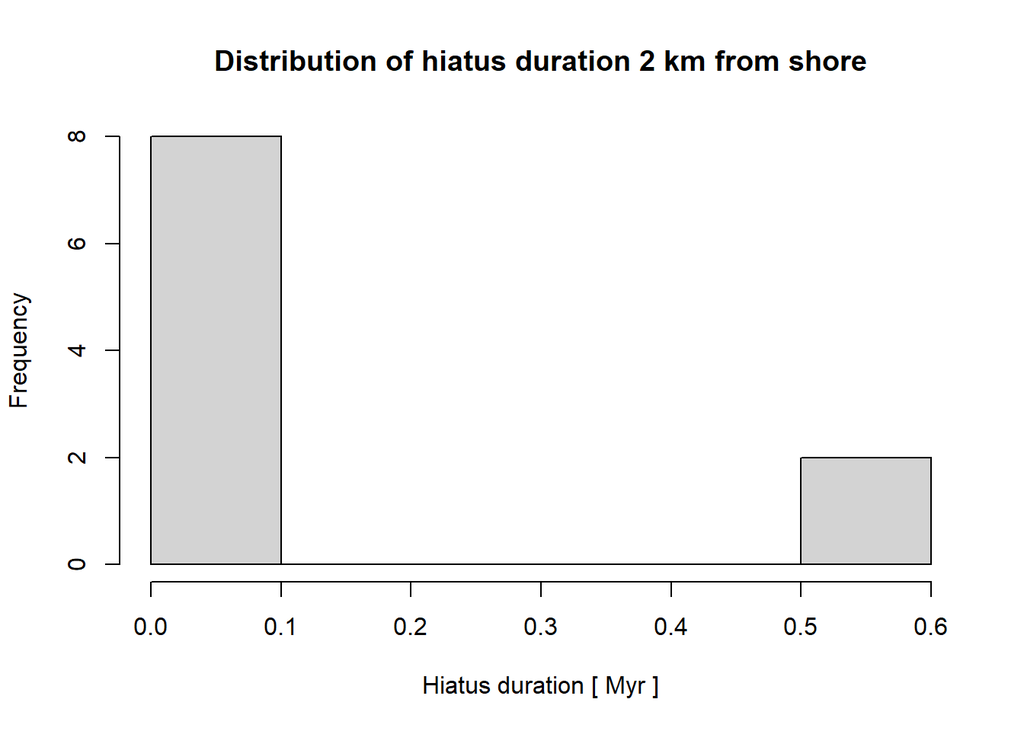

```r
adm |>                                                            # take age-depth model
  get_hiat_duration() |>                                          # extract hiatus durations
  hist(xlab = paste("Hiatus duration", "[", get_T_unit(adm),"]"), # make histogram
       main = "Distribution of hiatus duration 2 km from shore")
```

Similarly, you can plot age-depth models using

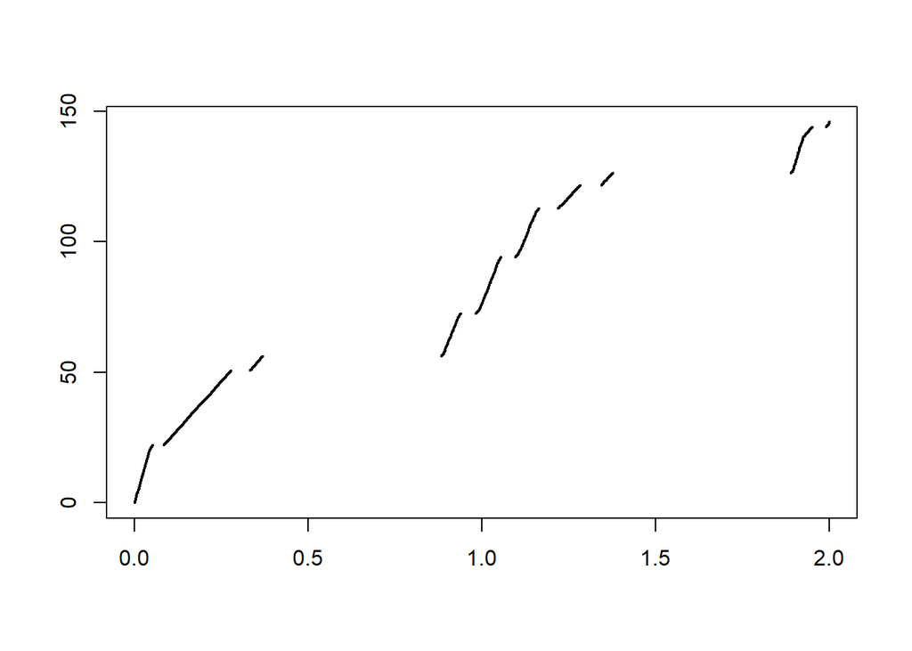

```r
adm |>                # take age-depth model
  plot(lwd_acc = 2,   # hand it to `plot`
       lty_destr = 0)
```

## Practical 2: Trait evolution (45 min)

This practical explores how trait evolution is influenced by stratigraphic architectures.

### Tasks

1. Plot the different modes of evolution in the time domain.
   - What is their internal variation due to randomness (i.e., how much do results differ if you plot them multiple times)?
   - What is the biological meaning of the model parameters?
2. Transform the different modes of evolution into the stratigraphic domain and plot them.
   - Which modes are most/least affected by stratigraphic biases?
   - Do you see any systematic changes?

### Coding cheat sheet

#### Modes of evolution in the time domain

There are three different modes of evolution implemented in the `StratPal` package: `stasis`, `random_walk`, and `ornstein_uhlenbeck`. You can plot them using piping via

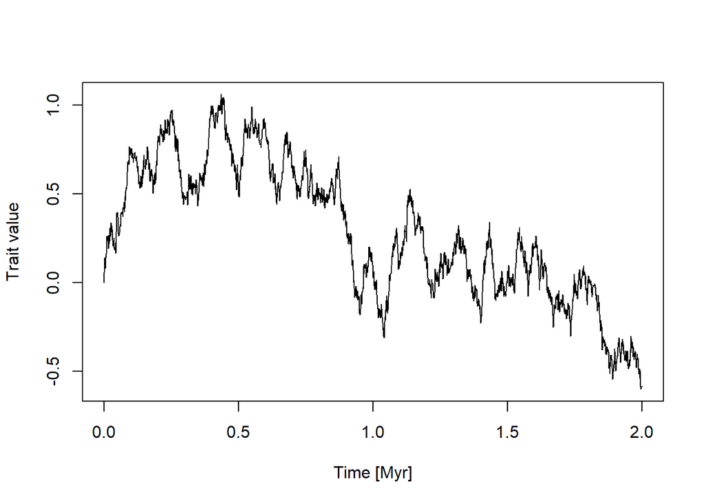

```r
temp_res = 0.001                                              # temporal resolution in Myr
seq(min_time(adm), max_time(adm), by = temp_res) |>           # time steps where the trait evolution is simulated
  random_walk(sigma = 1, mu = 0, y0 = 0) |>                   # simulate trait evolution
  plot(xlab = paste0("Time [",get_T_unit(adm),"]"),           # plot
       ylab = "Trait value",
       type = "l")
```

To plot other modes, replace `random_walk` by one of the other modes (`stasis` or `ornstein_uhlenbeck`).

#### Transforming trait evolution into the stratigraphic domain

To transform trait evolution into the stratigraphic domain, insert `time_to_strat` with the age-depth model of your choice into your pipeline:

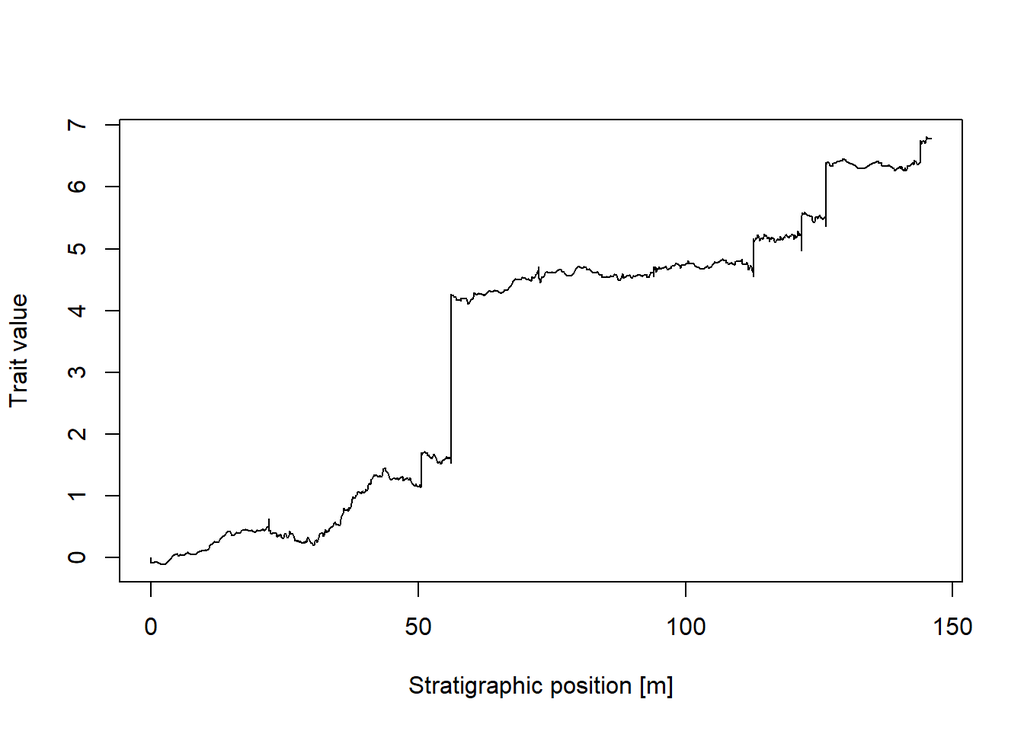

```r
temp_res = 0.001                                              # temporal resolution in Myr
seq(min_time(adm), max_time(adm), by = temp_res) |>           # time steps where the trait evolution is simulated
  random_walk(sigma = 1, mu = 3, y0 = 0) |>                   # simulate trait evolution
  time_to_strat(adm, destructive = FALSE) |>                  # transform into stratigraphic domain
  plot(xlab = paste0("Stratigraphic position [",get_L_unit(adm),"]"), # plot
       ylab = "Trait value",
       type = "l",
       orientation = "lr")
```

This will transform your simulations from the time domain into the stratigraphic domain.

## Practical 3: Niche modeling and last occurrences (45 min)

In this practical, we explore niche models, and how you can build your own mass extinction (BYOME) using stratigraphic paleobiology.

### Tasks niche modeling

1. Simulate an abundant taxon, and transform the fossil ages into the stratigraphic domain.
   - At which locations and stratigraphic heights do you observe peaks in fossil abundance?
   - With which stratigraphic effects are these peaks associated?
2. Define a niche for a taxon, and add the niche model to your pipeline.
   - How and why do your results change?
   - How could you misinterpret the results?

### Tasks last occurrences

3. Simulate last occurrences based on the assumption of a constant rate of last occurrences and transform them into the stratigraphic domain.
   - Where do you observe clusters of last occurrences?
   - With what stratigraphic effects are these locations associated?
   - How would you misinterpret the results in the absence of stratigraphic information? Use your results to formulate a “stratigraphic null hypothesis” for clusters of last occurrences.

### Coding cheat sheet

#### Simulating fossil occurrences

Fossil locations or ages can be simulated using the `p3` function if the rate of fossil occurrences is constant:

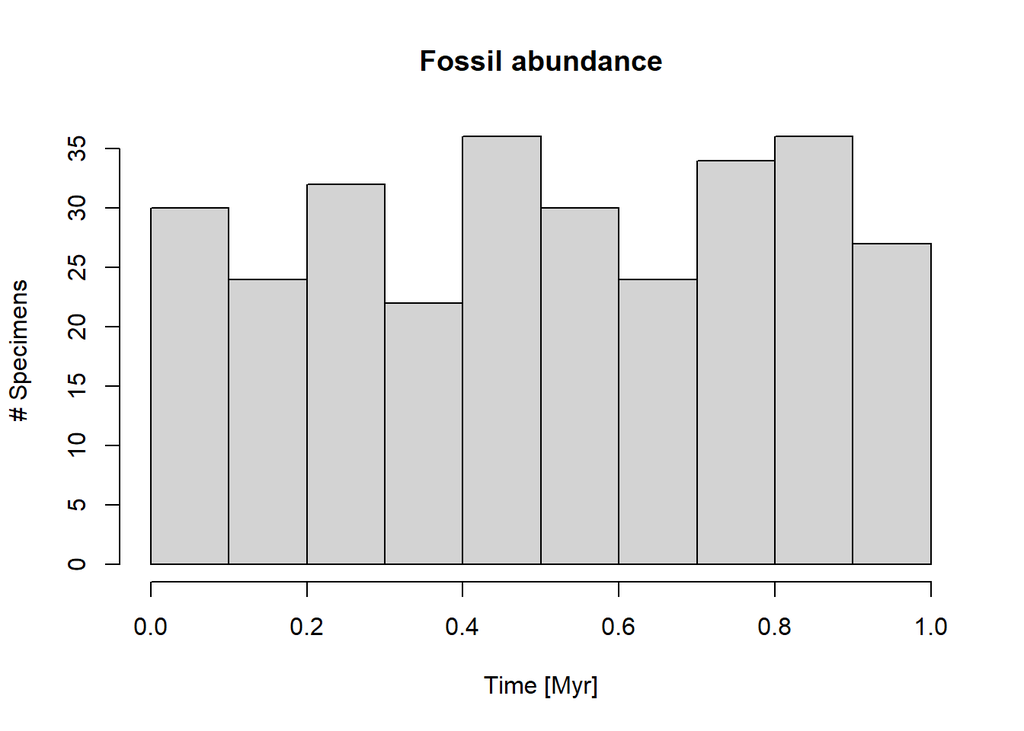

```r
rate = 300                           # 300 fossils per Myr
p3(rate = rate, from = 0, to = 1) |>
  hist(main = "Fossil abundance",
       xlab = "Time [Myr]",
       ylab = "# Specimens")
```

For time-variable rates see `p3_var_rate`.

#### Transforming fossil occurrences to the stratigraphic domain

You can transform fossil ages directly using `time_to_strat`:

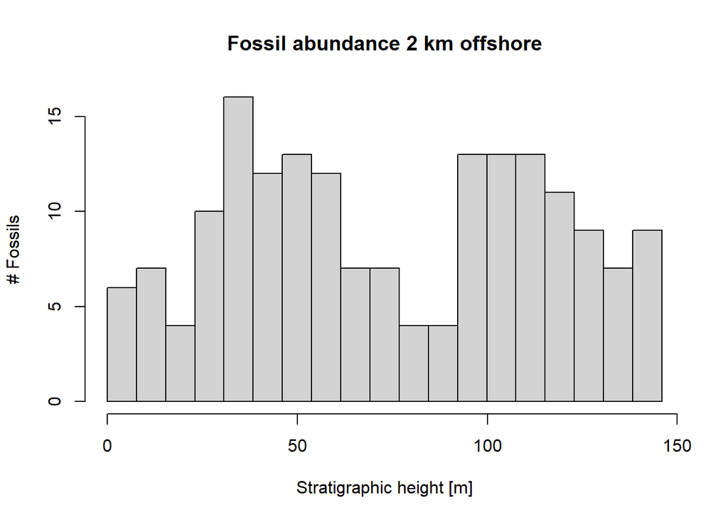

```r
foss_per_myr = 300                                                           # fossils per Myr
p3(rate = foss_per_myr, from = min_time(adm), to = max_time(adm)) |>         # constant rate in time domain
  time_to_strat(adm, destructive = TRUE) |>                                  # transform into depth domain
  hist(xlab = paste0("Stratigraphic height [",get_L_unit(adm),"]"),          # plot
       main = "Fossil abundance 2 km offshore",
       ylab = "# Fossils",
       breaks = seq(from = min_height(adm), to = max_height(adm), length.out = 20))
```

Note the option `destructive = TRUE` for `time_to_strat`. It makes sure fossils that coincide with hiatuses are destroyed.

#### Define niche models

```r
my_niche = snd_niche(opt = 10,       # preferred water depth
                     tol = 5,        # tolerance to water depth fluctuations
                     cutoff_val = 0) # cut off negative values - the taxon does not survive on land
```

To visualize the niche you can plot it using the following code:

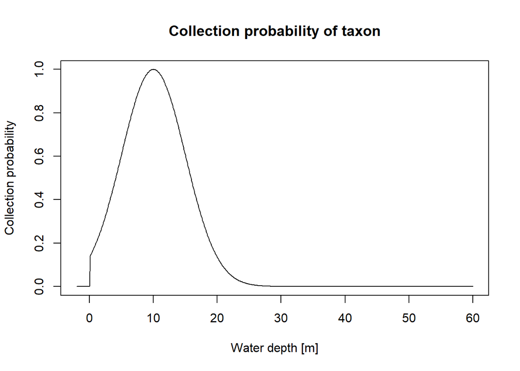

```r
max_wd = 60                                     # maximum water depth
x = seq(-2, max_wd, by = 0.1)
plot(x, my_niche(x),
     type = "l",
     xlab = "Water depth [m]",
     ylab = "Collection probability",
     main = "Collection probability of taxon")
```

#### Apply niche models

To apply a niche model, we need two components: A niche definition that specifies the niche of a taxon along a cline (water depth in this example - this is the function we defined above), and a function that describes how the cline changes with time.

To define a function that returns the water depth with time, you can use the following code:

```r
pos = "2km"                 # position in the platform we want water depth from
t = scenarioA$t_myr         # time steps where water depth is determined by the model
wd = scenarioA$wd_m[,pos]   # water depth 2 km from shore
gc = approxfun(t, wd)       # use linear interpolation between known water depths
```

You can visualize this function using the following code:

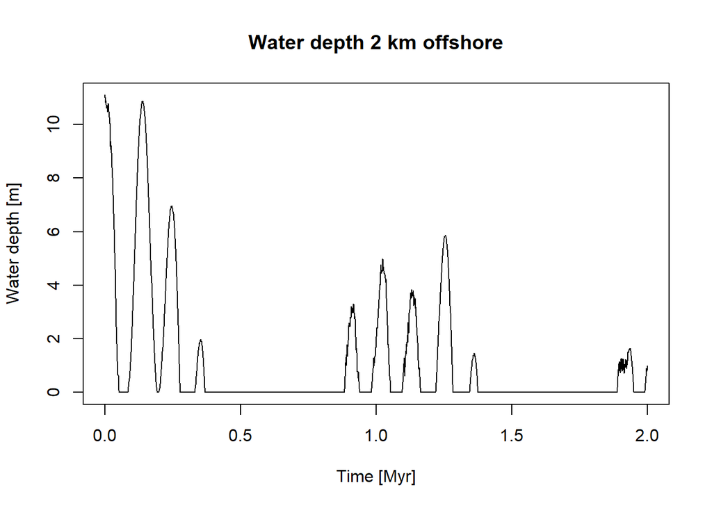

```r
plot(x = t,
     y = gc(t),
     type = "l",
     xlab = "Time [Myr]",
     ylab = "Water depth [m]",
     main = "Water depth 2 km offshore")
```

With both components (niche definition and cline change with time) defined, you can insert the niche model into the modeling pipeline via the function `apply_niche`:

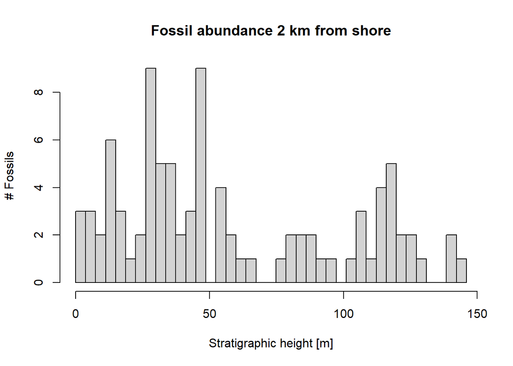

```r
p3(rate = foss_per_myr, from = min_time(adm), to = max_time(adm)) |>         # model occurrences based on constant rate
  apply_niche(niche_def = my_niche, gc = gc) |>                              # apply niche model
  time_to_strat(adm, destructive = TRUE) |>                                  # transform into strat. domain, destroy fossils that coincide with hiatuses
  hist(xlab = paste0("Stratigraphic height [",get_L_unit(adm) ,"]"),         # plot results
       main = "Fossil abundance 2 km from shore",
       ylab = "# Fossils",
       breaks = seq(from = min_height(adm), to = max_height(adm), length.out = 40))
```

#### Simulating and transforming last occurrences

Timing of last occurrences can be simulated using `p3` or `p3_var_rate` just as fossil occurrence (or any other type of “event” data). They can be transformed using `time_to_strat`:

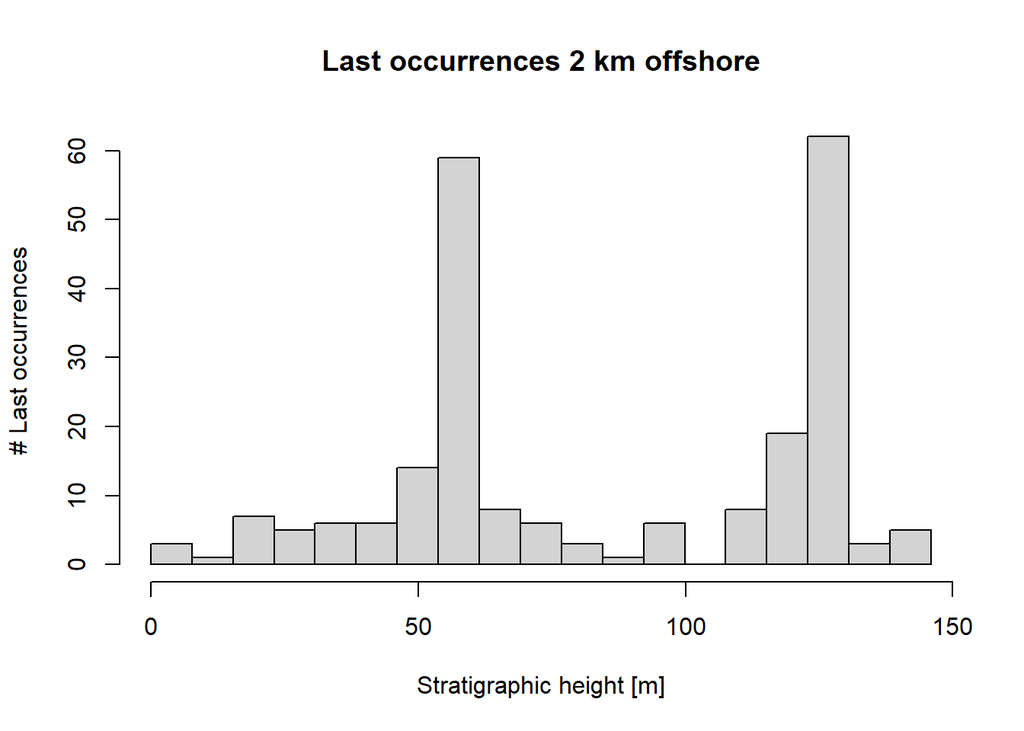

```r
rolo = 100                                                               # rate of last occurrences [per Myr]
p3(rate = rolo, from = min_time(adm), to = max_time(adm)) |>             # constant rate of last occ
  time_to_strat(adm, destructive = FALSE) |>                             # non-destructive transformation!
  hist(xlab = paste0("Stratigraphic height [",get_L_unit(adm),"]"),      # plot histogram
       main = "Last occurrences 2 km offshore",
       ylab = "# Last occurrences",
       breaks = seq(from = min_height(adm), to = max_height(adm), length.out = 20))
```

Note that we use the option `destructive = FALSE` in `time_to_strat`. This is because last occurrences during a hiatus will appear at the hiatus surface in the stratigraphic domain[^1].

## Footnotes

[^1]: What implicit assumption have we made here?